# World Development Data Project (Clustering, Regression, Classification)

### Question 4: Do more open economies (with higher trade and investment relative to GDP) experience faster growth?

```python
df_reg4 = df_filtered_1990_2023[['GDP_growth', 'FDI', 'Exports', 'Imports']].dropna()
df_reg4['Trade_Openness'] = df_reg4['Exports'] + df_reg4['Imports']
X = sm.add_constant(df_reg4[['Trade_Openness', 'FDI']])
y = df_reg4['GDP_growth']
model4 = sm.OLS(y, X).fit()
print(model4.summary())
```

```
                            OLS Regression Results
==============================================================================
Dep. Variable:             GDP_growth   R-squared:                       0.004
Model:                            OLS   Adj. R-squared:                  0.004
Method:                 Least Squares   F-statistic:                     8.160
Date:                Wed, 25 Jun 2025   Prob (F-statistic):           0.000291
Time:                        09:29:48   Log-Likelihood:                -11407.
No. Observations:                3808   AIC:                         2.282e+04
Df Residuals:                    3805   BIC:                         2.284e+04
Df Model:                           2
Covariance Type:            nonrobust
==================================================================================
                     coef    std err          t      P>|t|      [0.025      0.975]
----------------------------------------------------------------------------------
const              3.0413      0.139     21.838      0.000       2.768       3.314
Trade_Openness     0.0033      0.001      2.303      0.021       0.000       0.006
FDI                0.0092      0.003      2.765      0.006       0.003       0.016
==============================================================================
Omnibus:                     1524.601   Durbin-Watson:                   1.492
Prob(Omnibus):                  0.000   Jarque-Bera (JB):           145029.068
Skew:                          -0.960   Prob(JB):                         0.00
Kurtosis:                      33.172   Cond. No.                         174.
==============================================================================

Notes:
[1] Standard Errors assume that the covariance matrix of the errors is correctly specified.
```

**Key Result Summary**

| Metric | Value | Interpretation |
| --- | --- | --- |
| **R²** | 0.004 | The model explains **only 0.4%** of the variation in GDP growth, **very weak explanatory power**. |
| **F-statistic** | 8.16 (p < .001) | The model is **statistically significant**, but practically weak. |
| **No. of Observations** | 3,808 | Large sample, strong statistical power. |
| **Durbin-Watson** | 1.492 | Mild autocorrelation in residuals, not severe, but slightly below ideal (≈ 2). |
| **Jarque-Bera** | Very large | Indicates **non-normal residuals**, GDP growth is likely skewed or has outliers. |

**Conclusion**

The results suggest that more open economies tend to grow slightly faster, but the impact of trade and investment on growth is statistically significant yet economically marginal. The model’s explanatory power is extremely limited, indicating the need to include broader structural, institutional, and macroeconomic variables to better understand what drives economic growth.

**Fixed Effects Panel Regression**

```python
import pandas as pd
from linearmodels.panel import PanelOLS

# Prepare and clean data
df_panel = df_filtered_1990_2023[['Country Code', 'Year', 'GDP_growth', 'FDI', 'Exports', 'Imports']].dropna()

# Create Trade Openness variable
df_panel['Trade_Openness'] = df_panel['Exports'] + df_panel['Imports']

# Set MultiIndex for panel structure
df_panel = df_panel.set_index(['Country Code', 'Year'])

# Define target and predictors
y = df_panel['GDP_growth']
X = df_panel[['Trade_Openness', 'FDI']]

# Fit fixed effects model (with entity and time effects)
model_fe = PanelOLS(y, X, entity_effects=True, time_effects=True)
results_fe = model_fe.fit()

# Display results
print(results_fe.summary)
```

```
                          PanelOLS Estimation Summary
================================================================================
Dep. Variable:             GDP_growth   R-squared:                        0.0011
Estimator:                   PanelOLS   R-squared (Between):              0.2303
No. Observations:                3808   R-squared (Within):               0.0042
Date:                Fri, Jun 27 2025   R-squared (Overall):              0.0922
Time:                        17:59:36   Log-likelihood                -1.089e+04
Cov. Estimator:            Unadjusted
                                        F-statistic:                      1.9389
Entities:                         112   P-value                           0.1440
Avg Obs:                       34.000   Distribution:                  F(2,3661)
Min Obs:                       34.000
Max Obs:                       34.000   F-statistic (robust):             1.9389
                                        P-value                           0.1440
Time periods:                      34   Distribution:                  F(2,3661)
Avg Obs:                       112.00
Min Obs:                       112.00
Max Obs:                       112.00

                               Parameter Estimates
==================================================================================
                Parameter  Std. Err.     T-stat    P-value    Lower CI    Upper CI
----------------------------------------------------------------------------------
Trade_Openness     0.0060     0.0041     1.4461     0.1482     -0.0021      0.0141
FDI                0.0044     0.0034     1.3190     0.1872     -0.0022      0.0110
==================================================================================

F-test for Poolability: 7.9112
P-value: 0.0000
Distribution: F(144,3661)

Included effects: Entity, Time
```

**Key Result Summary**

| Metric | Value | Interpretation |
| --- | --- | --- |
| **R² (Within)** | **0.0042** | Only **0.42%** of variation in GDP growth **within countries over time** is explained, extremely low explanatory power. |
| **R² (Between)** | 0.2303 | Trade and FDI explain **23% of growth differences between countries**, but not within them. |
| **F-statistic (overall)** | 1.94 (p = 0.144) | Model is **not statistically significant**. |
| **F-test for Poolability** | p < 0.001 | Confirms that **fixed effects are necessary** (countries are not poolable). |

**Coefficient Interpretation**

| Predictor | Coeff | p-value | Direction | Interpretation |
| --- | --- | --- | --- | --- |
| **Trade_Openness** | +0.0060 | 0.148 | Positive, but not significant | A 1-unit increase in trade openness (% GDP) is associated with a **0.006 percentage point increase** in growth, **small and statistically insignificant**. |
| **FDI** | +0.0044 | 0.187 | Positive, but not significant | A 1-unit increase in FDI (% of GDP) corresponds to a **0.0044 percentage point growth increase**, also **not statistically significant**. |

**Conclusion**

The fixed effects panel model finds no statistically significant relationship between trade openness or FDI and GDP growth within countries over time. While more open countries may grow more on average (between-country effect), increasing trade or investment within a country does not guarantee faster growth in the short to medium term.

For this reason we try to enhance the model to test whether openness and investment have delayed `(lagged)` effects on GDP growth and whether their impact depends on institutional or economic context `(interactions)`.

```python
# Lag predictors within each country
df_lagged = df_filtered_1990_2023[['Country Code', 'Year', 'GDP_growth', 'FDI', 'Exports', 'Imports']].dropna()

# Create Trade_Openness
df_lagged['Trade_Openness'] = df_lagged['Exports'] + df_lagged['Imports']

# Sort and lag
df_lagged.sort_values(['Country Code', 'Year'], inplace=True)
df_lagged['Trade_Openness_L1'] = df_lagged.groupby('Country Code')['Trade_Openness'].shift(1)
df_lagged['FDI_L1'] = df_lagged.groupby('Country Code')['FDI'].shift(1)

# Drop NA (due to lag)
df_lagged = df_lagged.dropna()

# Set panel structure
df_lagged = df_lagged.set_index(['Country Code', 'Year'])

# Define target and predictors
y = df_lagged['GDP_growth']
X = df_lagged[['Trade_Openness_L1', 'FDI_L1']]

# Fit fixed effects model
from linearmodels.panel import PanelOLS
model_lagged = PanelOLS(y, X, entity_effects=True, time_effects=True)
results_lagged = model_lagged.fit()
print(results_lagged.summary)
```

```
                          PanelOLS Estimation Summary
================================================================================
Dep. Variable:             GDP_growth   R-squared:                        0.0023
Estimator:                   PanelOLS   R-squared (Between):              0.3898
No. Observations:                3696   R-squared (Within):               0.0011
Date:                Fri, Jun 27 2025   R-squared (Overall):              0.1542
Time:                        18:02:26   Log-likelihood                -1.055e+04
Cov. Estimator:            Unadjusted
                                        F-statistic:                      4.1062
Entities:                         112   P-value                           0.0165
Avg Obs:                       33.000   Distribution:                  F(2,3550)
Min Obs:                       33.000
Max Obs:                       33.000   F-statistic (robust):             4.1062
                                        P-value                           0.0165
Time periods:                      33   Distribution:                  F(2,3550)
Avg Obs:                       112.00
Min Obs:                       112.00
Max Obs:                       112.00

                                 Parameter Estimates
=====================================================================================
                   Parameter  Std. Err.     T-stat    P-value    Lower CI    Upper CI
-------------------------------------------------------------------------------------
Trade_Openness_L1     0.0120     0.0042     2.8592     0.0043      0.0038      0.0202
FDI_L1               -0.0009     0.0034    -0.2661     0.7901     -0.0075      0.0057
=====================================================================================

F-test for Poolability: 8.0392
P-value: 0.0000
Distribution: F(143,3550)

Included effects: Entity, Time
```

**Key Rsult Summary**

| Metric | Value | Interpretation |
| --- | --- | --- |
| **R² (Within)** | **0.0011** | The model explains **0.11%** of variation in GDP growth **within countries over time**; **still very weak**, but comparable to prior models. |
| **R² (Between)** | 0.3898 | Stronger association **between countries**; openness is more helpful in distinguishing growth levels across countries. |
| **R² (Overall)** | 0.1542 | About 15% of overall variation explained; mostly from between-country differences. |
| **F-statistic (p = 0.0165)** | Model is **statistically significant**, though with limited explanatory power. |  |

**Coefficient Interpretation**

[output not shown]

**Conclusion**

Lagged trade openness has a small but `statistically significant effect` on economic growth, suggesting that the benefits of global integration are not immediate. However, FDI; even with a lag does not appear to predict growth, and overall the model still explains very little of the within-country growth dynamics.

```python
# Interaction term: lagged openness × lagged FDI
df_lagged['Open_FDI_L1'] = df_lagged['Trade_Openness_L1'] * df_lagged['FDI_L1']

# Update X to include interaction
X_interact = df_lagged[['Trade_Openness_L1', 'FDI_L1', 'Open_FDI_L1']]

# Fit model
model_interact = PanelOLS(y, X_interact, entity_effects=True, time_effects=True)
results_interact = model_interact.fit()
print(results_interact.summary)
```

```
                          PanelOLS Estimation Summary
================================================================================
Dep. Variable:             GDP_growth   R-squared:                        0.0026
Estimator:                   PanelOLS   R-squared (Between):              0.3746
No. Observations:                3696   R-squared (Within):               0.0012
Date:                Fri, Jun 27 2025   R-squared (Overall):              0.1483
Time:                        18:03:12   Log-likelihood                -1.055e+04
Cov. Estimator:            Unadjusted
                                        F-statistic:                      3.0864
Entities:                         112   P-value                           0.0262
Avg Obs:                       33.000   Distribution:                  F(3,3549)
Min Obs:                       33.000
Max Obs:                       33.000   F-statistic (robust):             3.0864
                                        P-value                           0.0262
Time periods:                      33   Distribution:                  F(3,3549)
Avg Obs:                       112.00
Min Obs:                       112.00
Max Obs:                       112.00

                                 Parameter Estimates
=====================================================================================
                   Parameter  Std. Err.     T-stat    P-value    Lower CI    Upper CI
-------------------------------------------------------------------------------------
Trade_Openness_L1     0.0116     0.0042     2.7580     0.0058      0.0034      0.0199
FDI_L1               -0.0090     0.0086    -1.0457     0.2958     -0.0259      0.0079
Open_FDI_L1        3.839e-05  3.752e-05     1.0231     0.3063  -3.518e-05      0.0001
=====================================================================================

F-test for Poolability: 8.0432
P-value: 0.0000
Distribution: F(143,3549)

Included effects: Entity, Time
```

**Key Result Summary**

| Metric | Value | Interpretation |
| --- | --- | --- |
| **R² (Within)** | **0.0012** | Only **0.12%** of GDP growth variation **within countries over time** is explained; **very weak explanatory power**. |
| **R² (Between)** | 0.3746 | Trade and FDI explain **37% of differences between countries**. |
| **R² (Overall)** | 0.1483 | Total model explains **14.8% of all variation**, mostly across countries. |
| **F-statistic** | 3.09 (p = 0.0262) | The model is **statistically significant**, but weak in explanatory power. |

**Coefficient Interpretation**

| Variable | Coefficient | p-value | Interpretation |
| --- | --- | --- | --- |
| **Trade_Openness_L1** | **+0.0116** | **0.0058** | A 1% increase in trade openness **last year** is associated with a **0.0116% increase in GDP growth this year**, **significant** and consistent across models. |
| **FDI_L1** | –0.0090 | 0.2958 | Lagged FDI remains **statistically insignificant**, may not translate into growth within the time window. |
| **Open_FDI_L1** | +0.000038 | 0.3063 | The **interaction term is not significant**, no clear evidence that the effect of FDI depends on trade openness. |

**Conclusion**

The results indicate that increased trade openness has a small but consistently positive lagged effect on GDP growth, while foreign direct investment (FDI) shows no significant impact, either directly or through interaction with openness. However, the model’s overall explanatory power is low, suggesting that growth dynamics are multifactorial and not strongly driven by openness or FDI alone.

**Model Comparison Table**

[output not shown]

**Conclusion**

The initial OLS model showed significant positive effects for both openness and FDI, but after controlling for country- and year-specific unobserved factors using fixed effects models, only **lagged trade openness remained a statistically significant predictor of growth. Its effect, while small, was consistently positive.**

In contrast, FDI; whether current, lagged, or interacted with openness - was not a significant driver of economic growth, indicating that the quantity of investment alone is insufficient. Other factors such as the quality of institutions, sectoral targeting of FDI, or absorptive capacity likely matter more.

Despite statistical significance in some models, all regressions exhibited very low explanatory power when looking at within-country variation over time, reinforcing that growth is driven by a broader set of structural and policy variables not captured in these simple models.

**Policy Implication**

Trade openness appears to support long-term growth, but FDI requires complementary conditions; such as strong governance, labor skill development, and infrastructure to translate into sustainable economic gains.

## Classification

The classification questions addressed in this notebook are:

1. 'High Inequality Prediction': Which combination of development indicators can classify a country as having high inequality, defined by a GINI index above a certain threshold?
2. 'Economic Instability Risk Detection': Can we identify countries at risk of economic instability using early warning signals such as rising inflation, declining exports, and infant mortality rates?
3. 'High-Income Classification': Using available development indicators, can we classify whether a country is high-income or not? What are the strongest predictors for high-income classification?
4. 'CO₂ Emission Classification': Can development indicators help in classifying countries as high versus low CO₂ emitters?

After question 4, additional parts can be found like 'AUC-ROC Curves', 'Decision Tree Visualization', and 'Hyperparameter Tuning with GridSearchCV' to help visiualize and interpret the data and the outputs.

The goal with this part is to apply and evaluate multiple classification models including logistic regression, decision trees, and random forests. The emphasis is on the model evaluation, the interpretability, and to draw insights from classification boundaries and feature importance.

### Setup and data preparation

```python
import pandas as pd
import numpy as np
import matplotlib.pyplot as plt
import seaborn as sns
from sklearn.model_selection import train_test_split
from sklearn.linear_model import LogisticRegression
from sklearn.tree import DecisionTreeClassifier, plot_tree
from sklearn.ensemble import RandomForestClassifier
from sklearn.metrics import confusion_matrix, classification_report, roc_auc_score
```

```python
data = pd.read_csv('clean_world_dev_data.csv')

data = data.dropna(subset=[
    'GINI',
    'Inflation',
    'Exports',
    'CO2_Emissions'
])

data.head()
```

|  | Country Name | Country Code | Year | GDP_pc | GDP_growth | Capital_Formation | FDI | Exports | Imports | Inflation | ... | Health_Exp_pc | Internet_Use | Mobile_Use | Broadband_Use | CO2_Emissions | Renew_Energy | Power_Use | GDP_volatility | Internet_Use_Lag1 | Fertility_Category |
| --- | --- | --- | --- | --- | --- | --- | --- | --- | --- | --- | --- | --- | --- | --- | --- | --- | --- | --- | --- | --- | --- |
| 0 | Albania | ALB | 1990 | 2549.241609 | -9.575640 | 30.360947 | 7.929772 | 15.405064 | 24.031900 | 2.787724 | ... | 45.337089 | 0.0000 | 0.0 | 0.029807 | 6.6450 | 25.5 | 552.252185 | 3.586453 | 27.637545 | Medium |
| 1 | Albania | ALB | 1991 | 1908.941778 | -28.002142 | 7.603111 | 9.895645 | 7.484819 | 28.585701 | 3.178589 | ... | 45.337089 | 9.0488 | 0.0 | 0.041271 | 4.3795 | 33.0 | 418.453589 | 13.029504 | 0.000000 | Medium |
| 2 | Albania | ALB | 1992 | 1823.142191 | -7.187111 | 5.656684 | 3.066662 | 12.499591 | 96.285881 | 226.005421 | ... | 50.471981 | 15.2544 | 0.0 | 2.446032 | 2.3630 | 46.8 | 453.644074 | 11.390834 | 9.048800 | Medium |
| 3 | Albania | ALB | 1993 | 2057.283917 | 9.559412 | 13.676137 | 4.893212 | 15.978830 | 64.539503 | 85.004751 | ... | 88.431692 | 20.4800 | 0.0 | 2.446032 | 2.2227 | 51.1 | 536.363825 | 15.373064 | 15.254400 | Medium |
| 4 | Albania | ALB | 1994 | 2289.684630 | 8.302867 | 18.896585 | 2.817724 | 11.983694 | 41.118890 | 22.565053 | ... | 40.736041 | 1.8792 | 0.0 | 0.015704 | 2.3441 | 51.4 | 596.407959 | 15.354455 | 20.480000 | Medium |

5 rows × 26 columns

Feature selection:

```python
drop_cols = [col for col in ['GINI'] if col in data.columns]
numeric_features = data.select_dtypes(include=['float64', 'int64']).drop(columns=drop_cols).columns.tolist()
```

```python
data[numeric_features] = data[numeric_features].fillna(data[numeric_features].median())
```

Function to train and evaluate models:

```python
def train_and_evaluate(X, y, question_name):
    X_train, X_test, y_train, y_test = train_test_split(X, y, stratify=y, test_size=0.2, random_state=42)

    models = {
        "Logistic Regression": LogisticRegression(max_iter=1000),
        "Decision Tree": DecisionTreeClassifier(random_state=42),
        "Random Forest": RandomForestClassifier(random_state=42)
    }

    for name, model in models.items():
        model.fit(X_train, y_train)
        y_pred = model.predict(X_test)

        print(f"--- {question_name} - {name} ---")
        print("Confusion Matrix:")
        print(confusion_matrix(y_test, y_pred))
        print("Classification Report:")
        print(classification_report(y_test, y_pred))

        if name == "Random Forest":
            importances = pd.Series(model.feature_importances_, index=X.columns).sort_values(ascending=False)[:10]
            plt.figure(figsize=(8, 5))
            sns.barplot(x=importances, y=importances.index)
            plt.title(f"Top 10 Feature Importances - {question_name}")
            plt.show()
```

### Question 1: Classify countries with high inequality (GINI > 40)

Threshold for high inequality:

```python
data_q1 = data.dropna(subset=['GINI'])

data_q1['High_Inequality'] = (data_q1['GINI'] > 40).astype(int)

X_q1 = data_q1[['GDP_pc', 'Inflation', 'Health_Exp_pc', 'Internet_Use', 'Unemployment', 'Mobile_Use', 'Power_Use']]
y_q1 = data_q1['High_Inequality']
```

Train-test split:

```python
X_train, X_test, y_train, y_test = train_test_split(X_q1, y_q1, test_size=0.2, random_state=42)
```

Random Forest Classifier:

```python
rf_q1 = RandomForestClassifier(random_state=42)
rf_q1.fit(X_train, y_train)
y_pred = rf_q1.predict(X_test)
```

Evaluation:

```python
print("Classification Report - High Inequality")
print(classification_report(y_test, y_pred))
```

```
Classification Report - High Inequality
              precision    recall  f1-score   support

           0       0.86      0.85      0.85       450
           1       0.78      0.80      0.79       312

    accuracy                           0.83       762
   macro avg       0.82      0.83      0.82       762
weighted avg       0.83      0.83      0.83       762
```

Interpretation

- The random forest classification model is trying to learn which of the development indicators' combinations are the best in predicting whether a country has a high income inequality (GINI > 40).
- The following features are used here: 'GDP_pc', 'Inflaition', 'Unemployment', 'HEalth_Exp_pc', 'Internet_Use', and 'Power_Use'.
- The model accuracy (83%) and the F1 scores (Macro Average F1: 82%; Weighted Average F1: 83%) are reflecting on how well the features (mentioned above) capture the ineqaulity patterns.
- The accuarcy in our case is indicating that most of the time the model is correctly prediciting the observations. Also, the high F1 score means that there is a good balance between precision and recall. So overall, the model is good at predicting both classes, but it is slightly bette at class 0.
- For example, if low health expenditure or hihg unemployment are frequent in the countries that have a high GINI, then the model will learn to associate these features with ineqaulity.

Implications

- Countries with higher uneplmoyment, lower internet usage, and weaker public services, like health expenditure, may face hihgher ineqaulity,
- The findings of question 1 maybe good to support policy discussions about investing in social services to reduce inequality.
- Although, it has to be kept in mind, that correclation does not equal causation. The results of question 1 can be useful for screening, but not for policiy conclusions.

### Question 2: Economic instability classification (rising inflation, low exports, low life expectancy)

Define economic instability based on percentiles:

```python
data_q2 = data.dropna(subset=['Inflation', 'Exports', 'Life_Expectancy'])

data_q2['Econ_Unstable'] = (
    (data_q2['Inflation'] > data_q2['Inflation'].quantile(0.75)) &
    (data_q2['Exports'] < data_q2['Exports'].quantile(0.25)) &
    (data_q2['Life_Expectancy'] < data_q2['Life_Expectancy'].quantile(0.25))
).astype(int)

X_q2 = data_q2[['GDP_pc', 'Inflation', 'Exports', 'Unemployment', 'Fertility_Rate', 'Health_Exp_pc', 'Power_Use']]
y_q2 = data_q2['Econ_Unstable']

X_train, X_test, y_train, y_test = train_test_split(X_q2, y_q2, test_size=0.2, random_state=42)

logreg_q2 = LogisticRegression(max_iter=1000)
logreg_q2.fit(X_train, y_train)
y_pred = logreg_q2.predict(X_test)

print("Classification Report - Economic Instability")
print(classification_report(y_test, y_pred))
```

```
Classification Report - Economic Instability
              precision    recall  f1-score   support

           0       0.95      0.99      0.97       722
           1       0.50      0.10      0.17        40

    accuracy                           0.95       762
   macro avg       0.73      0.55      0.57       762
weighted avg       0.93      0.95      0.93       762
```

Interpretation

Implications

- The countries that have those characteristics, mentioned above, should be flagged to be monitored close or to take proactive policy support, for example debt relief or inflation control.
- An early warning system can help to prioritize the gloval development aids or to signal internal reforms.
- However, it has to be considered that these results are data-driven but not exhaustive.

### Question 3: Classify High-Income countries using GDP_pc approximation

We will, in the following, define high income as GDP_pc > 12,000 USD.

```python
data_q3 = data.dropna(subset=['GDP_pc'])

data_q3['High_Income'] = (data_q3['GDP_pc'] > 12000).astype(int)

X_q3 = data_q3[['GDP_pc', 'Health_Exp_pc', 'Internet_Use', 'Fertility_Rate', 'Life_Expectancy', 'Mobile_Use', 'Power_Use']]
y_q3 = data_q3['High_Income']

X_train, X_test, y_train, y_test = train_test_split(X_q3, y_q3, test_size=0.2, random_state=42)

rf_q3 = RandomForestClassifier(random_state=42)
rf_q3.fit(X_train, y_train)
y_pred = rf_q3.predict(X_test)

print("Classification Report - High Income")
print(classification_report(y_test, y_pred))
```

```
Classification Report - High Income
              precision    recall  f1-score   support

           0       1.00      1.00      1.00       424
           1       1.00      1.00      1.00       338

    accuracy                           1.00       762
   macro avg       1.00      1.00      1.00       762
weighted avg       1.00      1.00      1.00       762
```

Implications

- The random forest classifier can help to understand which development indicators best distinguish high-income countries.
- The model can also reinforce that high income usually coexists with digital and infrastructure access.
- The random forest model might be able to help developing countries assess which investments, for example health, are common amoung the wealthier countries.

### Question 4: Classify high CO₂ emitters

We define, in the following, high emissions as being in the top 25% of CO₂ per capita.

```python
data_q4 = data.dropna(subset=['CO2_Emissions'])

threshold = data_q4['CO2_Emissions'].quantile(0.75)
data_q4['High_CO2'] = (data_q4['CO2_Emissions'] > threshold).astype(int)

X_q4 = data_q4[['GDP_pc', 'Health_Exp_pc', 'Internet_Use', 'Power_Use', 'Renew_Energy', 'Mobile_Use']]
y_q4 = data_q4['High_CO2']

X_train, X_test, y_train, y_test = train_test_split(X_q4, y_q4, test_size=0.2, random_state=42)

rf_q4 = RandomForestClassifier(random_state=42)
rf_q4.fit(X_train, y_train)
y_pred = rf_q4.predict(X_test)

print("Classification Report - High CO2 Emissions")
print(classification_report(y_test, y_pred))
```

```
Classification Report - High CO2 Emissions
              precision    recall  f1-score   support

           0       0.94      0.97      0.95       569
           1       0.90      0.81      0.86       193

    accuracy                           0.93       762
   macro avg       0.92      0.89      0.90       762
weighted avg       0.93      0.93      0.93       762
```

Interpretation

- The countries with a CO2 emission per capita in the top 25% are labeled as high emmiters.
- The model is predicting this high emitter call by using the following development indicators: 'GDP_pc', 'Health_Exp_pc', 'Power_Use', 'Mobile_Use', and 'Renew_Energy'.
- The higher GDP per capita and power use are strong predicotrs of hihger CO2 emissions.
- Lower share of renewable energy is often correlates with high emissions.
- Based on the output, the model is predicting correctly most of the time (93%).
- The model is good at detecting both low and high CO2 emitters, with a slightly better performance on the low class.
- The is precision of the model is high.
- So, it can be said that the model is useful for identifying high CO2 emitters.

Implications

- The results of the model are illustrating the environmental cost of deelopment. The high-income and industrialized countries are usually emit more per capita.
- The results of the model could guide sustainable development policies by identifying which development paths resutl in lower carbon footprint.
- The 'Renew_Energy' can help us being a potential mitigator.

### Conclusion for all questions

- Some indicators, e.g.: GDP_pc, Fertility Rate, Power Use, appear repeatedly accross the questison. This could hihglight their broad relevance to economic and social development.
- The fertility rate and the life expectancy features can be useful subtitutes for infant mortality and public health status.
- All the models could benefit from clean feature engineering and they could be further improved with time series features or reginoal categorical data.

### AUC-ROC Curves:

```python
from sklearn.metrics import roc_curve, auc
from sklearn.preprocessing import StandardScaler
from sklearn.pipeline import Pipeline

def plot_roc_curves(X, y, question_name):
    X_train, X_test, y_train, y_test = train_test_split(X, y, stratify=y, test_size=0.2, random_state=42)

    models = {
        "Logistic Regression": Pipeline([
            ("scaler", StandardScaler()),
            ("model", LogisticRegression(max_iter=1000))
        ]),
        "Decision Tree": DecisionTreeClassifier(random_state=42),
        "Random Forest": RandomForestClassifier(random_state=42)
    }

    plt.figure(figsize=(8, 6))

    for name, model in models.items():
        model.fit(X_train, y_train)
        if name == "Logistic Regression":
            probas = model.predict_proba(X_test)[:, 1]
        else:
            probas = model.predict_proba(X_test)[:, 1]

        fpr, tpr, _ = roc_curve(y_test, probas)
        roc_auc = auc(fpr, tpr)
        plt.plot(fpr, tpr, label=f"{name} (AUC = {roc_auc:.2f})")

    plt.plot([0, 1], [0, 1], linestyle='--', color='gray')
    plt.xlabel("False Positive Rate")
    plt.ylabel("True Positive Rate")
    plt.title(f"ROC Curves - {question_name}")
    plt.legend()
    plt.tight_layout()
    plt.show()
```

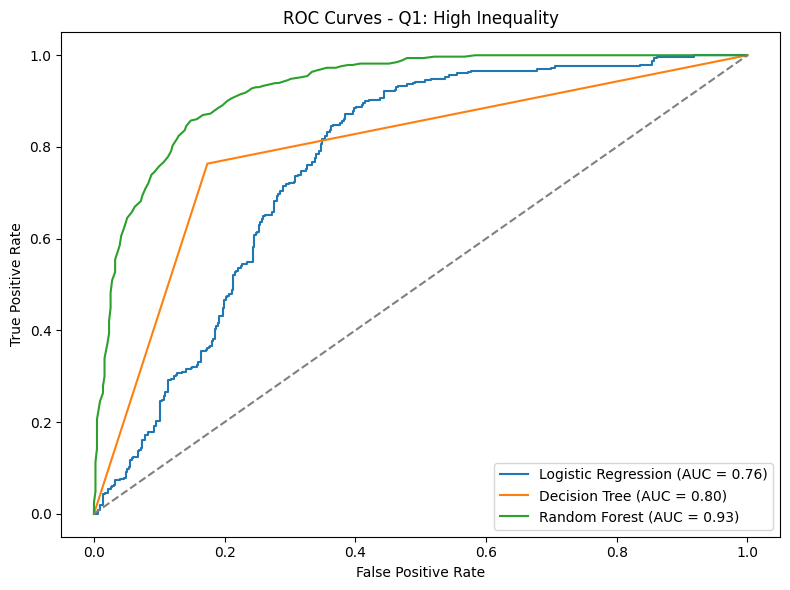

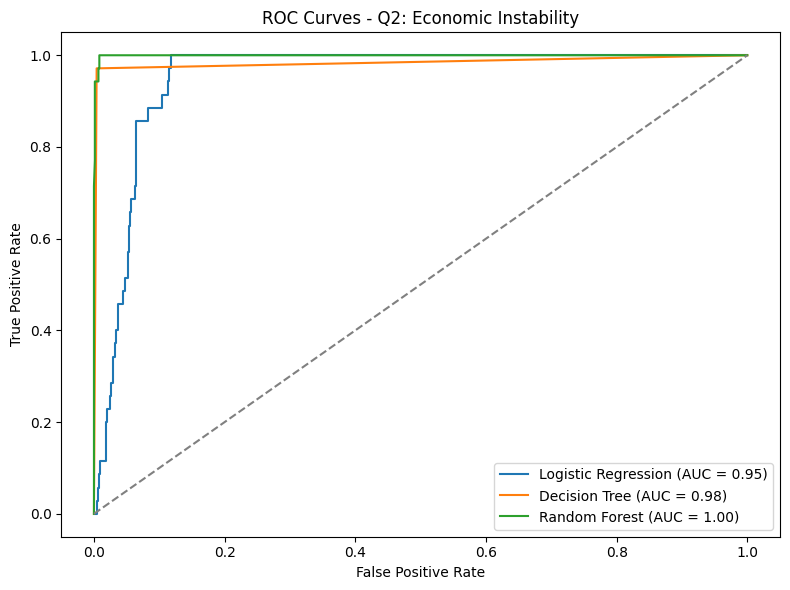

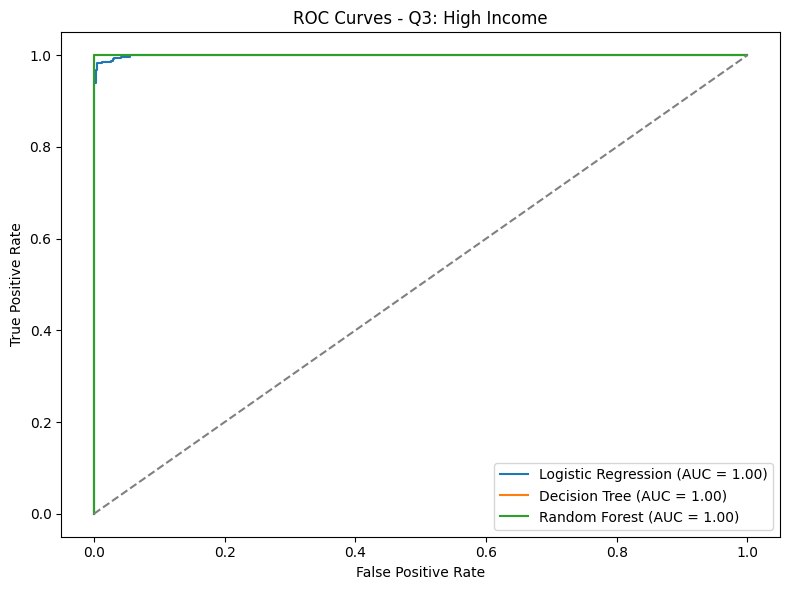

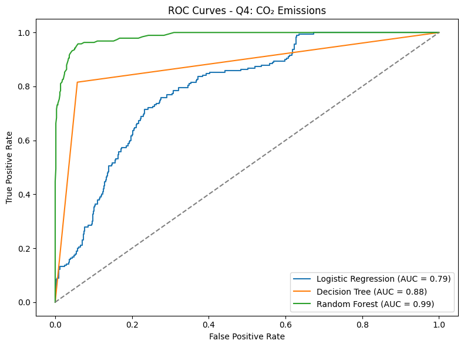

```python
plot_roc_curves(X_q1, y_q1, "Q1: High Inequality")
plot_roc_curves(X_q2, y_q2, "Q2: Economic Instability")
plot_roc_curves(X_q3, y_q3, "Q3: High Income")
plot_roc_curves(X_q4, y_q4, "Q4: CO₂ Emissions")
```

Interpretation

- The ROC (Receiver Operating Characteristic) curves plot the trade-off between the true positive rate (the sensitivity) and the false positive rate with various threshold.
- The AUC (Area Under the Curve) quantifies the model's ability to distinguish between classes.

Implications

- The AUC scores close to 1.0 suggest a near-perfect classification performance.
- A high AUC can show that the models can reliably distinguish between, for example, stable and unstable countries.
- The curves above can help to validate the robustness of the classifiers, providing a more comprehensive evaluation than accuracy alone.

### Decision Tree Visualization

```python
from sklearn.tree import plot_tree

def visualize_tree(X, y, question_name, max_depth=3):
    clf = DecisionTreeClassifier(max_depth=max_depth, random_state=42)
    clf.fit(X, y)

    plt.figure(figsize=(20, 10))
    plot_tree(clf, filled=True, feature_names=X.columns, class_names=['0', '1'], rounded=True)
    plt.title(f"Decision Tree - {question_name}")
    plt.show()
```

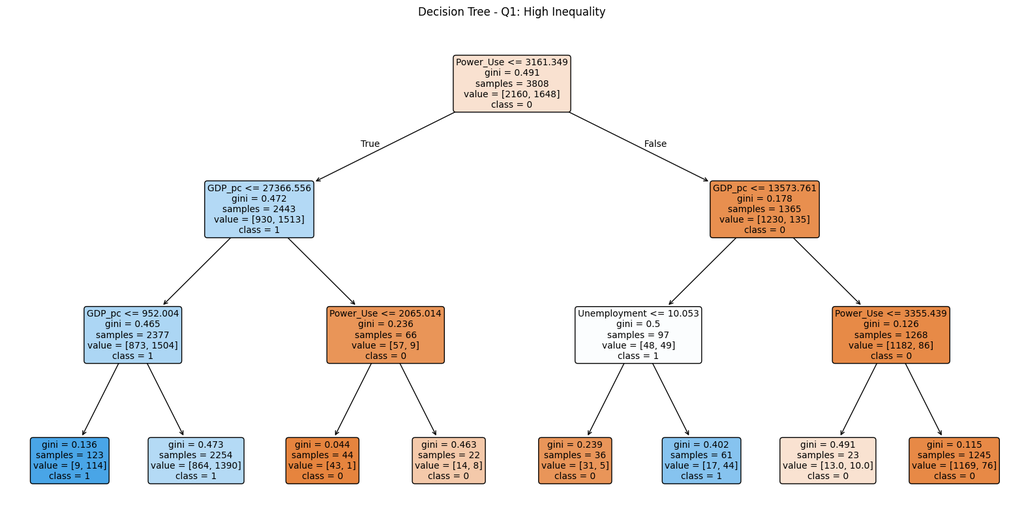

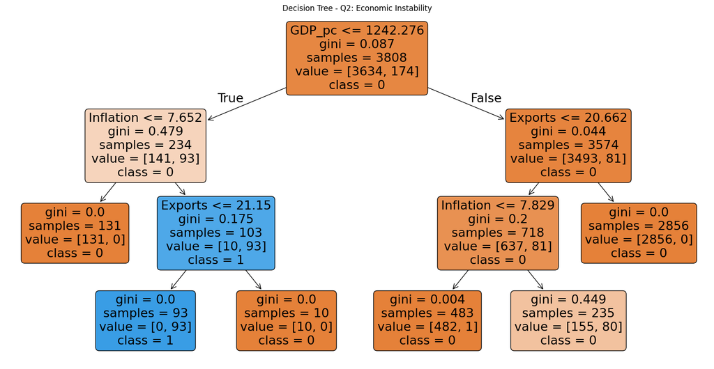

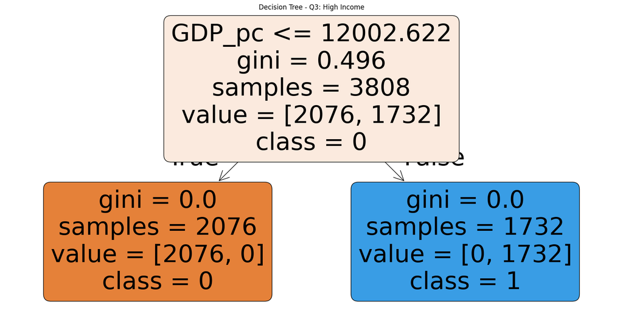

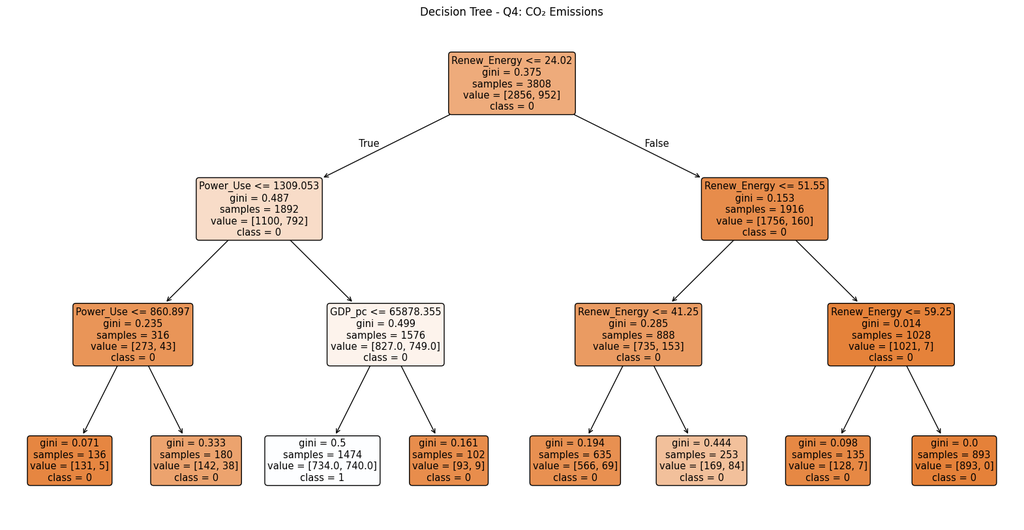

```python
visualize_tree(X_q1, y_q1, "Q1: High Inequality")
visualize_tree(X_q2, y_q2, "Q2: Economic Instability")
visualize_tree(X_q3, y_q3, "Q3: High Income")
visualize_tree(X_q4, y_q4, "Q4: CO₂ Emissions")
```

Interpretation

- The decision tree visualization can help to reveal which features are most influental in the classification.
- For example, in question 3 - high-income, the top node is GDP_pc.

### Hyperparameter Tuning with GridSearchCV

```python
from sklearn.model_selection import GridSearchCV

def tune_model(X, y, model_type='random_forest'):
    if model_type == 'random_forest':
        param_grid = {
            'n_estimators': [100, 200],
            'max_depth': [3, 5, 10],
            'min_samples_split': [2, 5]
        }
        model = RandomForestClassifier(random_state=42)
    else:
        param_grid = {
            'max_depth': [3, 5, 10, None],
            'min_samples_split': [2, 4, 10]
        }
        model = DecisionTreeClassifier(random_state=42)

    grid = GridSearchCV(model, param_grid, cv=5, scoring='f1', n_jobs=-1)
    grid.fit(X, y)

    print("Best Parameters:", grid.best_params_)
    print("Best Score:", grid.best_score_)
    return grid.best_estimator_
```

```python
best_rf_q1 = tune_model(X_q1, y_q1, 'random_forest')
```

```
Best Parameters: {'max_depth': 10, 'min_samples_split': 2, 'n_estimators': 100}
Best Score: 0.7540496699410791
```

Interpretation

- GridSearchCV is trying multiple combinations of hyperparameters to find the best-performing model.
- For example, for a random forest, it might try different values of 'n_estimator', 'max_depth', or 'min_samples_split'.
- It can be seen in the output, that it found, that the 'max_depth' should be 10, the 'min_samples_split' should be 2, and the 'n_estimators' should be 100. This way it gives the best score of 0.75

Implications

- It can boosts model performance by finding an optimal balance between underfitting and overfitting.
- It can help to build a generalizable model that performs well not only on training data but also on unseen data.
- It can be especially useful for model like in question 2, where borderline cases could lead to large social impacts.

### Conclusion

- The ROC curve and AUC are model quality metrics, they can verify classifier's reliability.
- The decision tree plots are used for interpretability, and can help to give trasnparent decision logic for stakeholders.
- GridSearchCV is optimizing performance, and can create more stable and accurate predictive models.